# Project1

Most people seem to be of average fitness but there are more above this than below and more at 5 than 4

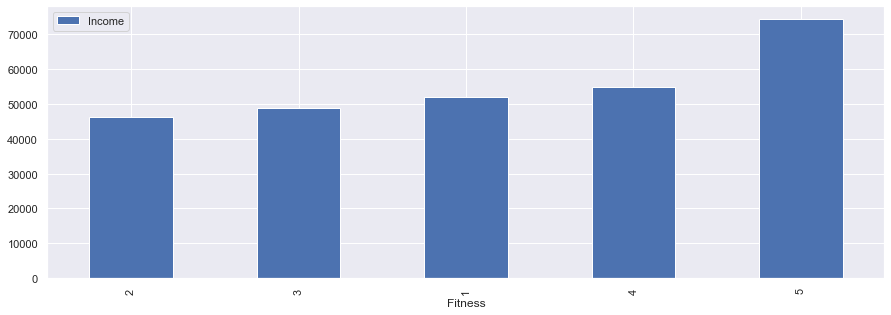

```python
Cardio.groupby(by=['Fitness'])['Income'].mean().reset_index().sort_values(['Income']).tail(10).plot(x='Fitness', y='Income', kind='bar', figsize=(15,5))
plt.show()
```

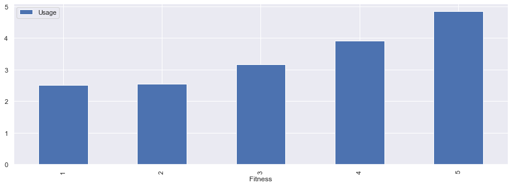

```python
Cardio.groupby(by=['Fitness'])['Usage'].mean().reset_index().sort_values(['Usage']).head(10).plot(x='Fitness', y='Usage', kind='bar', figsize=(15,5))
plt.show()
```

There seems to be an interesting trend where more for people (4 and 5) have higher incomes. Logically, people with higher fitness tend to use the product more

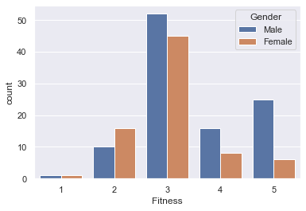

```python
sns.countplot(Cardio['Fitness'],hue=Cardio['Gender'])
plt.show()
```

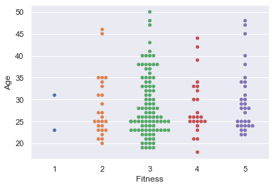

```python
sns.swarmplot(x='Fitness',y='Age',data=Cardio)
plt.show()
```

TM195 is most popular. Lets see if this is true for income, gender, education, age, usage, and fitness.

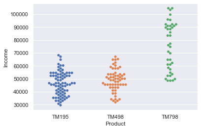

```python
sns.swarmplot(x='Product',y='Income',data=Cardio)
plt.show()
```

TM195 and TM498 are both relatively normal in their discribution based on income while tm798 is extremely popular amonst higher income people (90,000-100,000), neither other product is ised by people making above 70,000

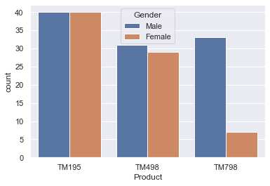

```python
sns.countplot(Cardio['Product'], hue=Cardio['Gender'])
plt.show()
```

There are more men than women so it seems TM195 and TM498 are (propertionally) more popular with women while TM798 is signifcantly more popular with men

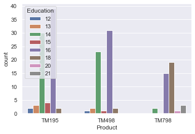

```python
sns.countplot(Cardio['Product'], hue=Cardio['Education'])
plt.show()
```

TM195 and TM498 seem to be popular amongst those with 14 or 16 years of education and are the only onesbought by thoise with 12,13, or 15 years of education. TM798 seem to be popular with people with 16 or 18 years od edcation and is the only product purcashed by people with 20-21 years of education, this adds to the trends in income we saw earlier

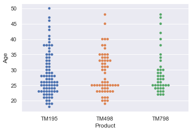

```python
sns.swarmplot(x='Product',y='Age',data=Cardio)
plt.show()
```

There does not look to be a bias in age for product, though no one under 22 bught TM798, perhaps adding to the income trend noted earlier

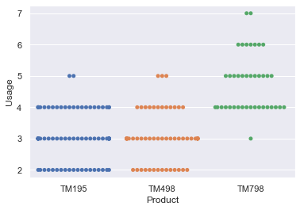

```python
sns.swarmplot(x='Product',y='Usage',data=Cardio)
plt.show()
```

TM195 abd TM498 are not used more than 5 times a week (or the user doesn't intend to use them more than this) TM798 is never used 1 or 2 times a week and rarley lss than 4. Indeed this is the only one used more than 5 times a week. I would be interested to see if there is a relationship between usage and income, due to both being associated with higher usage of TM798

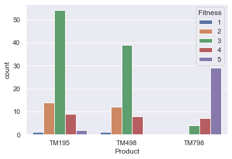

```python
sns.countplot(Cardio['Product'], hue=Cardio['Fitness'])
plt.show()
```

Most people of average or below fitness purchase TM195 or TM498, and indeed no one below fitness 3 buys TM798. There are fewer people buying TM798 so it seems fitness 4 prefer that one and those of fitness 5 strongly prefer TM798, none buy TM498 and only a few buy TM195. I would be interested to see if there is a relationship between income and fitness as both prefer TM798

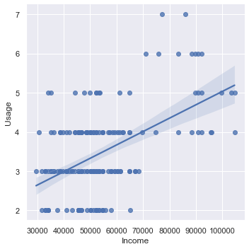

```python
sns.lmplot(x='Income',y='Usage',data=Cardio)
plt.show()
```

People making less than 70,000 excercise 2-5 times a wee with most doing so 2-4. Those making above 70,000 do not excercise less 4 times a week and some (2) between 75,0000 and 85,000 work out 7 times a week.

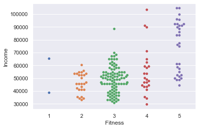

```python
sns.swarmplot(x='Fitness',y='Income',data=Cardio)
plt.show()
```

It may seem tirival, but lets see if theres is a rleationship betwene education and income

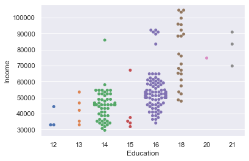

```python
sns.swarmplot(x='Education',y='Income',data=Cardio)
plt.show()
```

There seems to be a relationship between years of education and income, with those having atleat 18 making the most money

Miles shouldn'y be too different from usage, but lets look at how it correlates with prodct

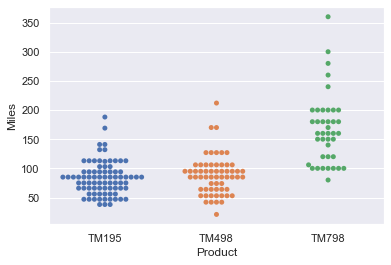

```python
sns.swarmplot(x='Product',y='Miles',data=Cardio)
plt.show()
```

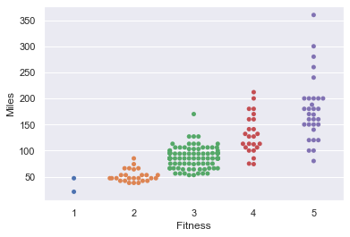

```python
sns.swarmplot(x='Fitness',y='Miles',data=Cardio)
plt.show()
```

As expected, the results are similiar to usage, TM798 sees more milage than the other two. Aidtionally, more fit people tend to have higher miliage with no one other than group 5 being above about 225 Finally, lets see is maritial status is related to product, income, or usage

More partnered people than single (110 vs 70)

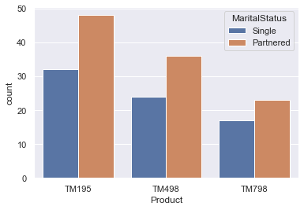

```python
sns.countplot(Cardio['Product'], hue=Cardio['MaritalStatus'])
plt.show()
```

There does not appear to be any significant difference in product based on marital status

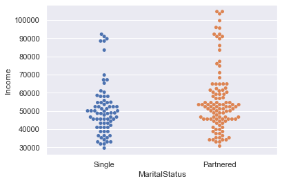

```python
sns.swarmplot(x='MaritalStatus',y='Income',data=Cardio)
plt.show()
```

There seem to be no significant difference in income based on marital status, though single people don't male more than about 90,000 dollars while a few married people do

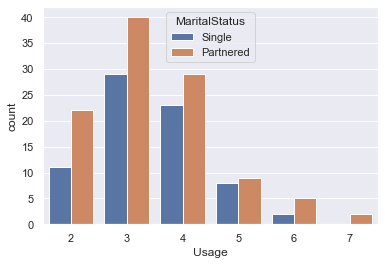

```python
sns.countplot(Cardio['Usage'], hue=Cardio['MaritalStatus'])
plt.show()
```

Partnered people seem to be more likely to workout 2,6, and 7 times a week while single people seem more likely to excercise 5 times

Overall i'd recomend marketting the TM798 to more fit and higher income people and the others to a more gneral audience. I'd also recommend marketting all product in areas where young adults live and specifically the TM798 in areas where those with higher education live and work. I do not see a reason to market to men over women or couples over single people, but the strategies in those two will obviously vary. It may be a good idea to have some kind of optional premium subscription for the TM798 as it is preffered by high income people who may be willing to pay I would also like to recommend a less expensive option that what we offer as we are not bringing in anyone of below average income. Let's finish with a pairplot to make sure we didn't miss anyhting

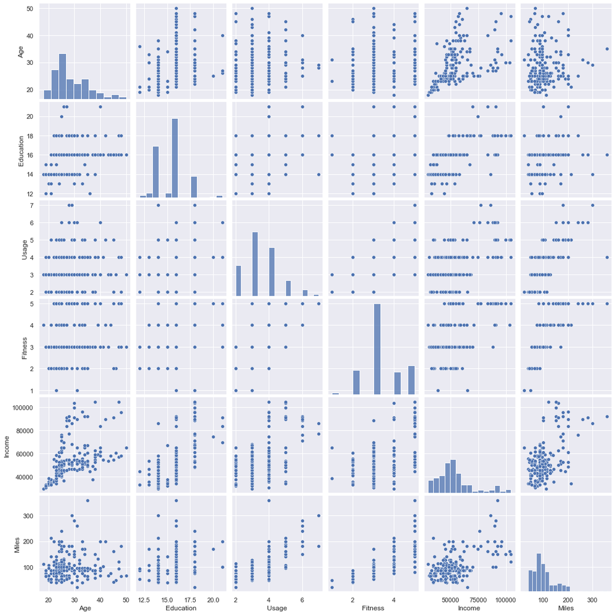

```python
sns.pairplot(Cardio)
```

I don't see anyhing major worht looking at

Ryan Mansfield